# Class 2/Lab1: Training, Evaluating, and Resampling Models

Week 2 (9.04)

## Introduction

In this lab, we will build the toolkit for training and evaluating statistical learning models. Using simulated data, we will:

1. Calculate common performance metrics (RMSE, Accuracy, Silhouette Score, Explained Variance) by hand, so the formulas behind `caret`/`yardstick` output stop being a black box.
2. Fit polynomials of increasing degree to the same data and watch training error keep falling while test error eventually turns back up — the bias-variance tradeoff.
3. Use the bootstrap to estimate the standard error and a confidence interval for a statistic without relying on a textbook formula.

```r
# Clear environment and unload packages
rm(list = ls())
pacman::p_unload(pacman::p_loaded())

# Load necessary packages
pacman::p_load(tidyverse, patchwork, cluster)
```

### Evaluation Metrics

#### RMSE (Regression)

RMSE measures the average magnitude of the errors between predicted and actual values — the square root of the average squared difference.

$$RMSE =
\sqrt{\frac{1}{n}\sum_{i=1}^{n}(predicted_i - actual_i)^2}$$

```r
set.seed(42)
rmse_data <- data.frame(
  ID = 1:10,
  Actual = round(runif(10, 50, 150), 1),
  Predicted = round(runif(10, 50, 150), 1)
) %>%
  mutate(Error = Predicted - Actual,
         Squared_Error = Error^2)

knitr::kable(rmse_data, caption = "Toy actual vs. predicted values")
```

Toy actual vs. predicted values

| ID | Actual | Predicted | Error | Squared_Error |
| --- | --- | --- | --- | --- |
| 1 | 141.5 | 95.8 | -45.7 | 2088.49 |
| 2 | 143.7 | 121.9 | -21.8 | 475.24 |
| 3 | 78.6 | 143.5 | 64.9 | 4212.01 |
| 4 | 133.0 | 75.5 | -57.5 | 3306.25 |
| 5 | 114.2 | 96.2 | -18.0 | 324.00 |
| 6 | 101.9 | 144.0 | 42.1 | 1772.41 |
| 7 | 123.7 | 147.8 | 24.1 | 580.81 |
| 8 | 63.5 | 61.7 | -1.8 | 3.24 |
| 9 | 115.7 | 97.5 | -18.2 | 331.24 |
| 10 | 120.5 | 106.0 | -14.5 | 210.25 |

```r
mse <- mean(rmse_data$Squared_Error)
rmse <- sqrt(mse)

cat("MSE  =", round(mse, 2), "\n")
```

```
## MSE  = 1330.39
```

```r
cat("RMSE =", round(rmse, 2), "\n")
```

```
## RMSE = 36.47
```

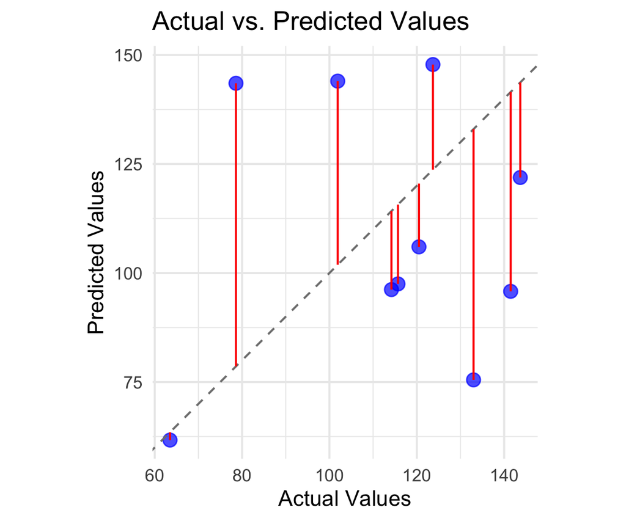

```r
ggplot(rmse_data, aes(x = Actual, y = Predicted)) +
  geom_point(color = "blue", size = 4, alpha = 0.7) +
  geom_abline(intercept = 0, slope = 1, linetype = "dashed", color = "gray50") +
  geom_segment(aes(xend = Actual, yend = Actual), color = "red") +
  labs(title = "Actual vs. Predicted Values", x = "Actual Values", y = "Predicted Values") +
  theme_minimal(base_size = 15) +
  coord_equal()
```

**Interpretation:** The red segments are the residuals that get squared in the RMSE formula. Points far from the dashed 1:1 line contribute disproportionately to RMSE because the errors are squared before averaging.

#### Accuracy (Classification)

Accuracy is the proportion of correct predictions among all cases evaluated — the most common classification metric, though it can be misleading on imbalanced data.

$$Accuracy = \frac{True\,Positives +
True\,Negatives}{Total\,Samples}$$

```r
set.seed(42)
accuracy_data <- data.frame(
  ID = 1:20,
  Actual = factor(sample(0:1, 20, replace = TRUE)),
  Predicted = factor(sample(0:1, 20, replace = TRUE, prob = c(0.6, 0.4)))
)

cm <- table(Actual = accuracy_data$Actual, Predicted = accuracy_data$Predicted)
cm
```

```
##       Predicted
## Actual 0 1
##      0 4 5
##      1 5 6
```

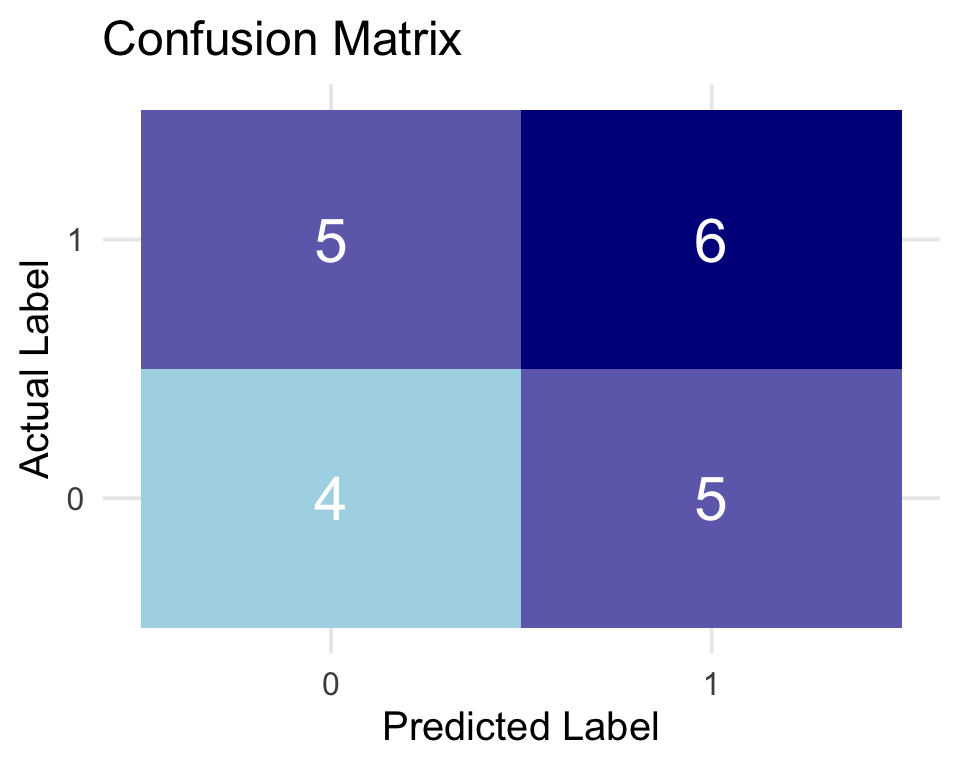

```r
cm_df <- as.data.frame(cm)

ggplot(cm_df, aes(x = Predicted, y = Actual, fill = Freq)) +
  geom_tile() +
  geom_text(aes(label = Freq), size = 8, color = "white") +
  scale_fill_gradient(low = "lightblue", high = "darkblue") +
  labs(title = "Confusion Matrix", x = "Predicted Label", y = "Actual Label") +
  theme_minimal(base_size = 15) +
  theme(legend.position = "none")
```

```r
tp <- cm[2, 2]
tn <- cm[1, 1]
total <- sum(cm)
acc <- (tp + tn) / total

cat("True Positives:", tp, "\n")
```

```
## True Positives: 6
```

```r
cat("True Negatives:", tn, "\n")
```

```
## True Negatives: 4
```

```r
cat("Accuracy = (", tp, "+", tn, ") /", total, "=", round(acc, 3), "\n")
```

```
## Accuracy = ( 6 + 4 ) / 20 = 0.5
```

#### Silhouette Score (Clustering)

The silhouette score measures how similar a point is to its own cluster (cohesion) versus the nearest other cluster (separation). It ranges from -1 to +1; higher is better.

$$s(i) = \frac{b(i) - a(i)}{\max(a(i),
b(i))}$$

where $a(i)$ is the average distance from point $i$ to other points in its own cluster, and $b(i)$ is the average distance from $i$ to points in the nearest neighboring cluster.

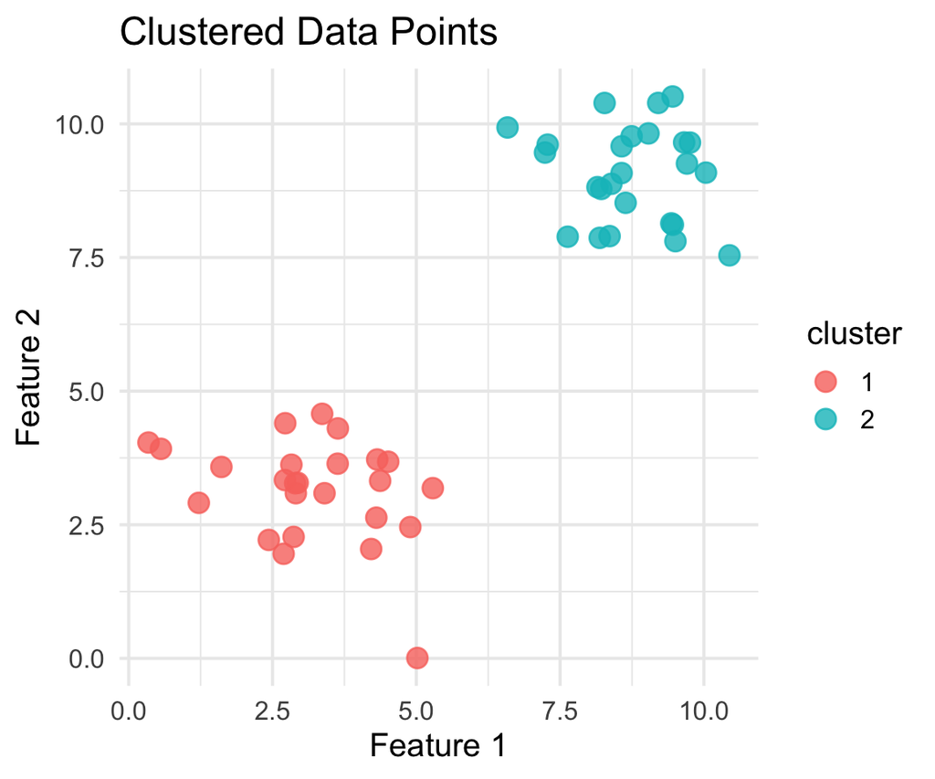

```r
set.seed(42)
silhouette_data <- data.frame(
  x = c(rnorm(25, 3, 1), rnorm(25, 9, 1)),
  y = c(rnorm(25, 3, 1), rnorm(25, 9, 1))
)

km <- kmeans(silhouette_data, centers = 2, nstart = 25)

silhouette_data$cluster <- as.factor(km$cluster)
ggplot(silhouette_data, aes(x = x, y = y, color = cluster)) +
  geom_point(size = 4, alpha = 0.8) +
  labs(title = "Clustered Data Points", x = "Feature 1", y = "Feature 2") +
  theme_minimal(base_size = 15)
```

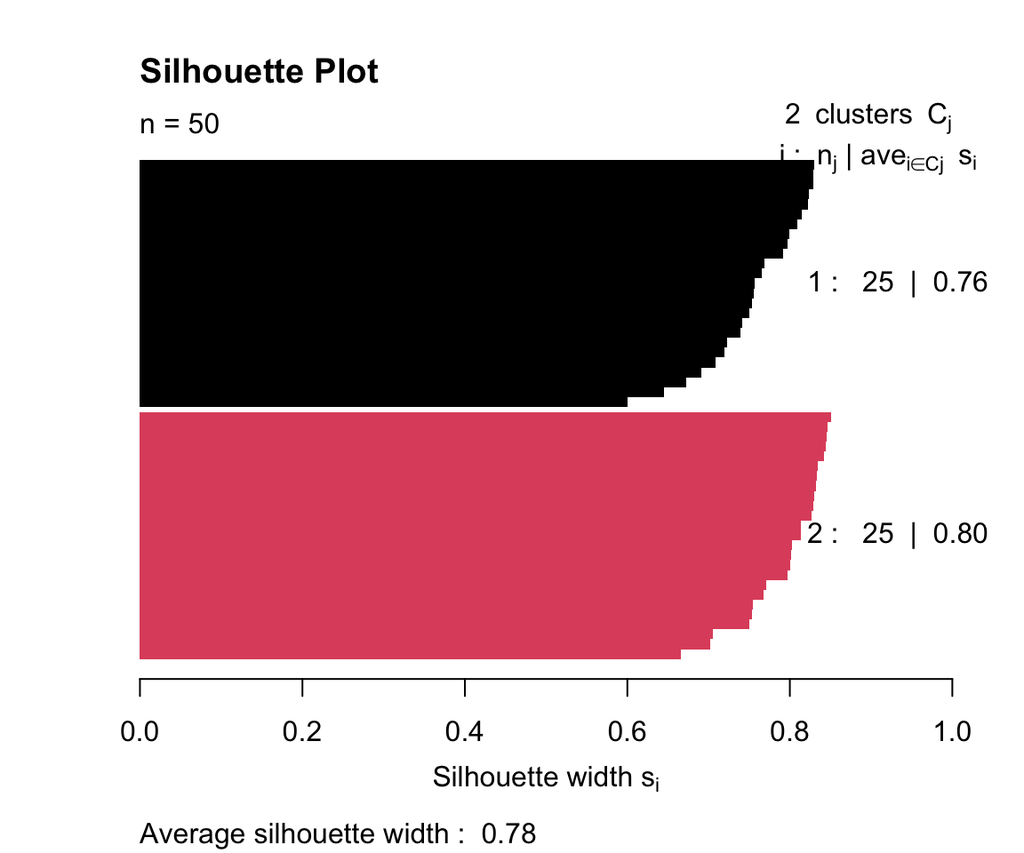

```r
dist_matrix <- dist(silhouette_data[, c("x", "y")])
sil <- silhouette(km$cluster, dist_matrix)

plot(sil, col = 1:2, border = NA, main = "Silhouette Plot")
```

```r
cat("Average Silhouette Score =", round(mean(sil[, "sil_width"]), 3), "\n")
```

```
## Average Silhouette Score = 0.777
```

#### Explained Variance (Dimensionality Reduction)

In PCA, explained variance is the proportion of total variance captured by each principal component — used to decide how many components to keep.

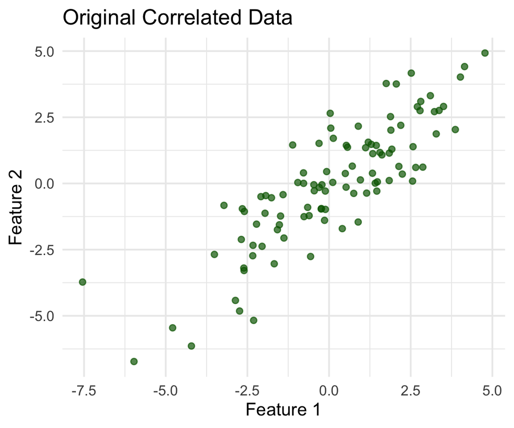

```r
set.seed(42)
cov_matrix <- matrix(c(5, 4, 4, 5), nrow = 2)
ev_data <- as.data.frame(MASS::mvrnorm(n = 100, mu = c(0, 0), Sigma = cov_matrix))
names(ev_data) <- c("Feature_1", "Feature_2")

ggplot(ev_data, aes(x = Feature_1, y = Feature_2)) +
  geom_point(alpha = 0.7, color = "darkgreen") +
  labs(title = "Original Correlated Data", x = "Feature 1", y = "Feature 2") +
  theme_minimal(base_size = 15)
```

```r
pca_result <- prcomp(ev_data, scale. = TRUE)
vars <- pca_result$sdev^2
props <- vars / sum(vars)

ev_df <- data.frame(
  Component = paste0("PC", seq_along(vars)),
  Variance = round(vars, 3),
  Proportion_of_Variance = round(props, 3),
  Cumulative_Proportion = round(cumsum(props), 3)
)

knitr::kable(ev_df)
```

| Component | Variance | Proportion_of_Variance | Cumulative_Proportion |
| --- | --- | --- | --- |
| PC1 | 1.846 | 0.923 | 0.923 |
| PC2 | 0.154 | 0.077 | 1.000 |

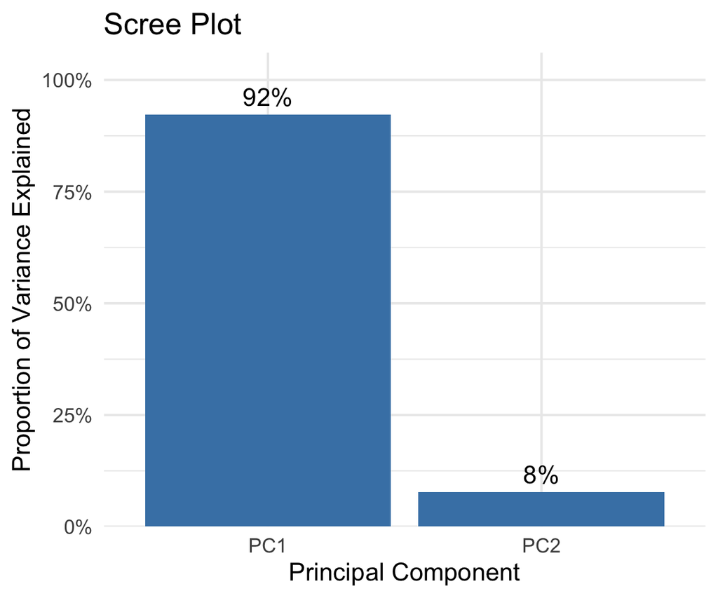

```r
ev_df$Component <- factor(ev_df$Component, levels = ev_df$Component)

ggplot(ev_df, aes(x = Component, y = Proportion_of_Variance)) +
  geom_col(fill = "steelblue") +
  geom_text(aes(label = scales::percent(Proportion_of_Variance)), vjust = -0.5) +
  labs(title = "Scree Plot", x = "Principal Component", y = "Proportion of Variance Explained") +
  theme_minimal(base_size = 15) +
  scale_y_continuous(labels = scales::percent, expand = expansion(mult = c(0, 0.15)))
```

**Interpretation:** The first principal component explains 92% of the total variance — unsurprising, since we constructed `Feature_1` and `Feature_2` to be strongly correlated.

### Bias-Variance Tradeoff

Here we generate data from a known nonlinear function, then fit polynomials of increasing degree and track training vs. test error. Low-degree models underfit (high bias); high-degree models overfit (high variance).

```r
set.seed(42)
n <- 100
noise_sd <- 0.5

x <- seq(-2, 2, length.out = n)
true_y <- sin(x^2)
observed_y <- true_y + rnorm(n, mean = 0, sd = noise_sd)

df <- data.frame(x = x, y = observed_y, true_y = true_y)

train_indices <- sample(1:n, size = round(0.7 * n))
train_data <- df[train_indices, ]
test_data <- df[-train_indices, ]
```

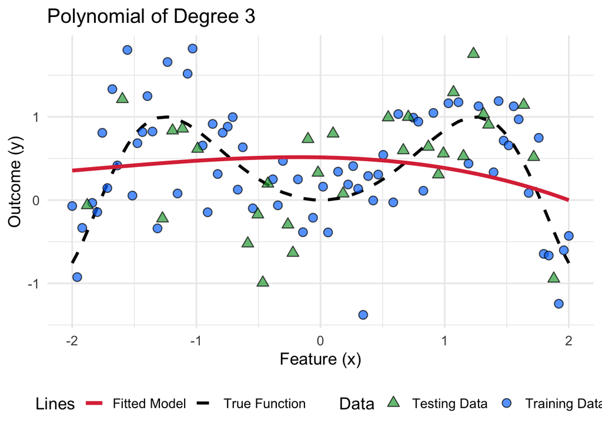

```r
# Fit a single low-degree polynomial for illustration
degree <- 3
fit <- lm(y ~ poly(x, degree = degree, raw = TRUE), data = train_data)

x_curve <- seq(min(train_data$x), max(train_data$x), length.out = 200)
y_curve <- predict(fit, newdata = data.frame(x = x_curve))

ggplot() +
  geom_line(data = train_data, aes(x = x, y = true_y, color = "True Function"), linewidth = 1.2, linetype = "dashed") +
  geom_point(data = train_data, aes(x = x, y = y, fill = "Training Data"), shape = 21, size = 3, alpha = 0.7) +
  geom_point(data = test_data, aes(x = x, y = y, fill = "Testing Data"), shape = 24, size = 3, alpha = 0.7) +
  geom_line(data = data.frame(x = x_curve, y = y_curve), aes(x = x, y = y, color = "Fitted Model"), linewidth = 1.5) +
  scale_color_manual(name = "Lines", values = c("True Function" = "black", "Fitted Model" = "#dc3545")) +
  scale_fill_manual(name = "Data", values = c("Training Data" = "#007bff", "Testing Data" = "#28a745")) +
  labs(title = paste("Polynomial of Degree", degree), x = "Feature (x)", y = "Outcome (y)") +
  theme_minimal(base_size = 14) +
  theme(legend.position = "bottom")
```

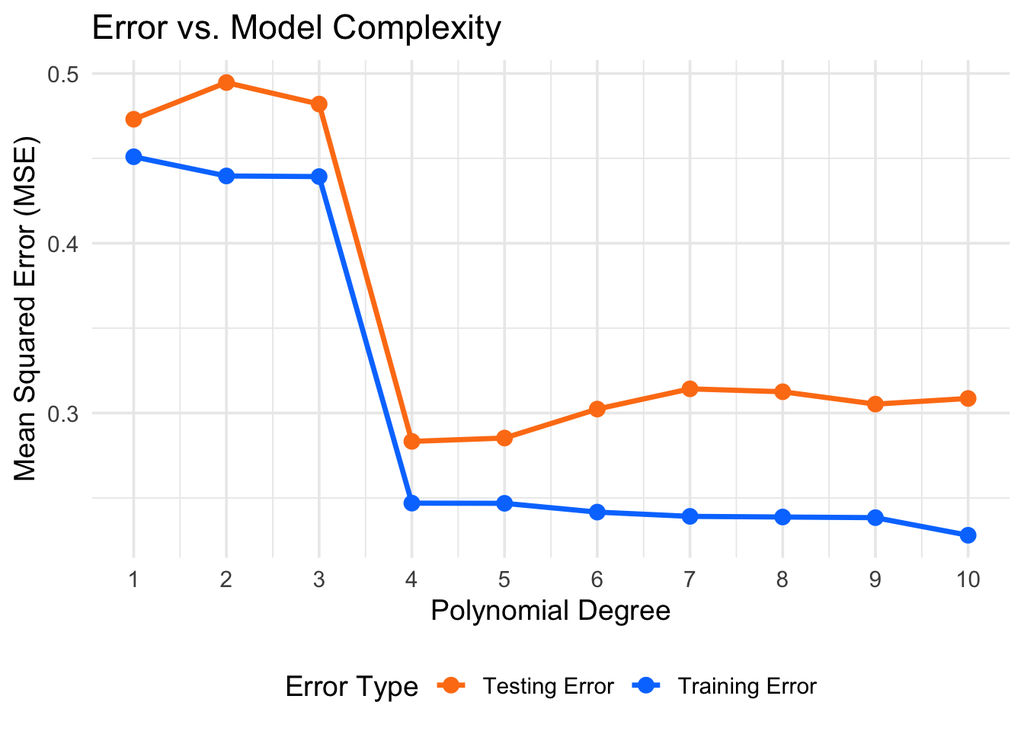

```r
max_degree <- 10

error_data <- sapply(1:max_degree, function(d) {
  model <- lm(y ~ poly(x, degree = d, raw = TRUE), data = train_data)
  train_mse <- mean((train_data$y - predict(model, newdata = train_data))^2)
  test_mse  <- mean((test_data$y  - predict(model, newdata = test_data))^2)
  c(degree = d, train_mse = train_mse, test_mse = test_mse)
}) %>%
  t() %>%
  as.data.frame() %>%
  pivot_longer(cols = c(train_mse, test_mse), names_to = "type", values_to = "mse")

ggplot(error_data, aes(x = degree, y = mse, color = type, group = type)) +
  geom_line(linewidth = 1.2) +
  geom_point(size = 3) +
  scale_color_manual(name = "Error Type",
                      labels = c("train_mse" = "Training Error", "test_mse" = "Testing Error"),
                      values = c("train_mse" = "#007bff", "test_mse" = "#fd7e14")) +
  scale_x_continuous(breaks = 1:max_degree) +
  labs(title = "Error vs. Model Complexity", x = "Polynomial Degree", y = "Mean Squared Error (MSE)") +
  theme_minimal(base_size = 14) +
  theme(legend.position = "bottom")
```

**Interpretation:** Training error decreases (almost) monotonically as we add flexibility — the model can always fit the training points more closely. Test error decreases at first as bias drops, then rises again once the model starts fitting noise instead of signal. The degree at which test error is minimized is the sweet spot in the bias-variance tradeoff for this dataset.

### The Bootstrap

The bootstrap estimates the sampling distribution of a statistic by resampling the observed data with replacement, without relying on a closed-form formula for its standard error.

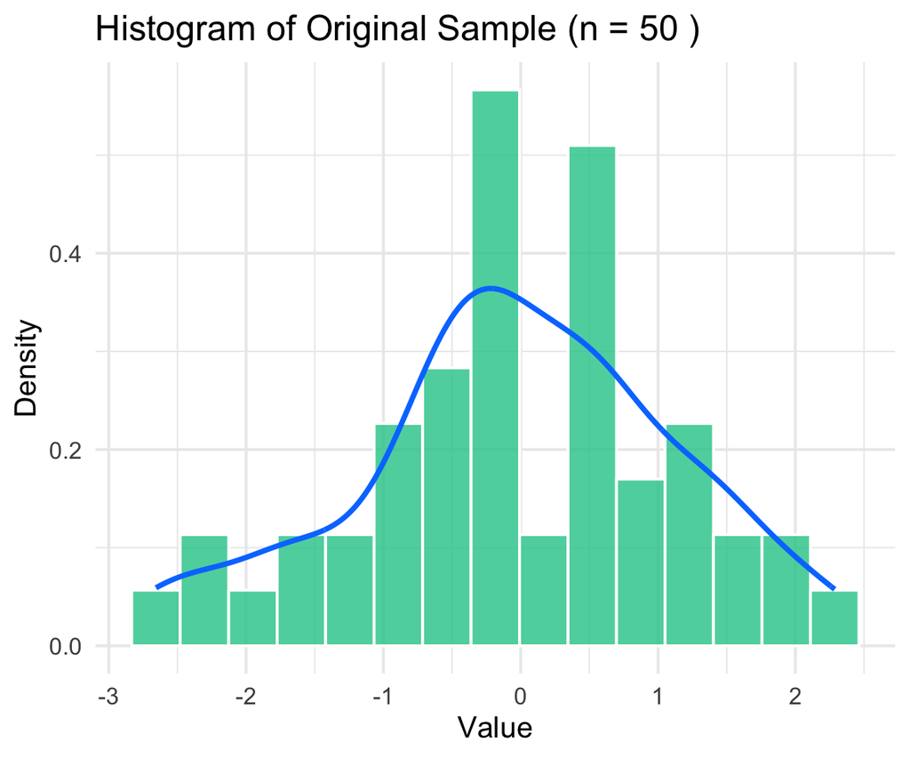

```r
set.seed(42)
n_sample <- 50
original_sample <- rnorm(n_sample, mean = 0, sd = 1)

ggplot(data.frame(value = original_sample), aes(x = value)) +
  geom_histogram(aes(y = after_stat(density)), bins = 15, fill = "#20c997", color = "white", alpha = 0.8) +
  geom_density(color = "#007bff", linewidth = 1.2) +
  labs(title = paste("Histogram of Original Sample (n =", n_sample, ")"), x = "Value", y = "Density") +
  theme_minimal(base_size = 14)
```

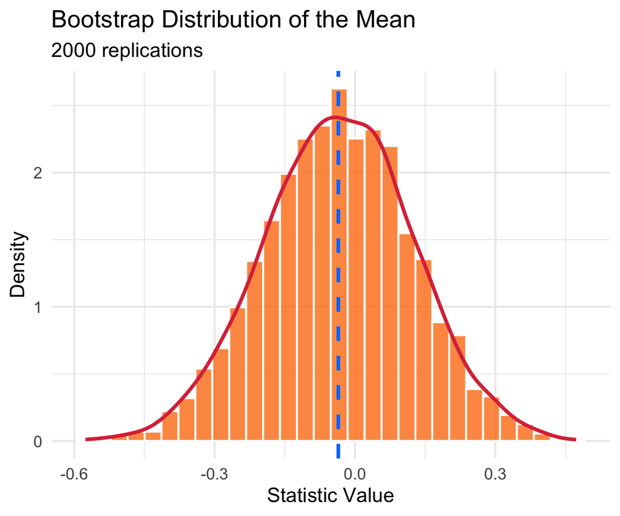

```r
B <- 2000
statistic_fn <- mean

boot_stats <- replicate(B, {
  boot_sample <- sample(original_sample, size = n_sample, replace = TRUE)
  statistic_fn(boot_sample)
})

original_stat <- statistic_fn(original_sample)

ggplot(data.frame(statistic = boot_stats), aes(x = statistic)) +
  geom_histogram(aes(y = after_stat(density)), bins = 30, fill = "#fd7e14", color = "white", alpha = 0.8) +
  geom_density(color = "#dc3545", linewidth = 1.2) +
  geom_vline(xintercept = original_stat, color = "#007bff", linetype = "dashed", linewidth = 1.2) +
  labs(title = "Bootstrap Distribution of the Mean", subtitle = paste(B, "replications"),
       x = "Statistic Value", y = "Density") +
  theme_minimal(base_size = 14)
```

```r
boot_se <- sd(boot_stats)
boot_ci <- quantile(boot_stats, probs = c(0.025, 0.975))

cat("Original statistic:", round(original_stat, 4), "\n")
```

```
## Original statistic: -0.0357
```

```r
cat("Bootstrap SE:      ", round(boot_se, 4), "\n")
```

```
## Bootstrap SE:       0.1585
```

```r
cat("95% CI:             [", round(boot_ci[1], 4), ",", round(boot_ci[2], 4), "]\n")
```

```
## 95% CI:             [ -0.3515 , 0.279 ]
```

**Interpretation:** The bootstrap SE and CI closely match what the Central Limit Theorem predicts for the mean of a normal sample ($\sigma/\sqrt{n}$), which is why the bootstrap is trustworthy here — and why it’s most useful for statistics (medians, correlations, model coefficients) where no such closed-form formula exists.

#### Trying a different statistic

Swap `statistic_fn` for another summary to see how the bootstrap distribution changes shape — e.g. the standard deviation, which is right-skewed in small samples:

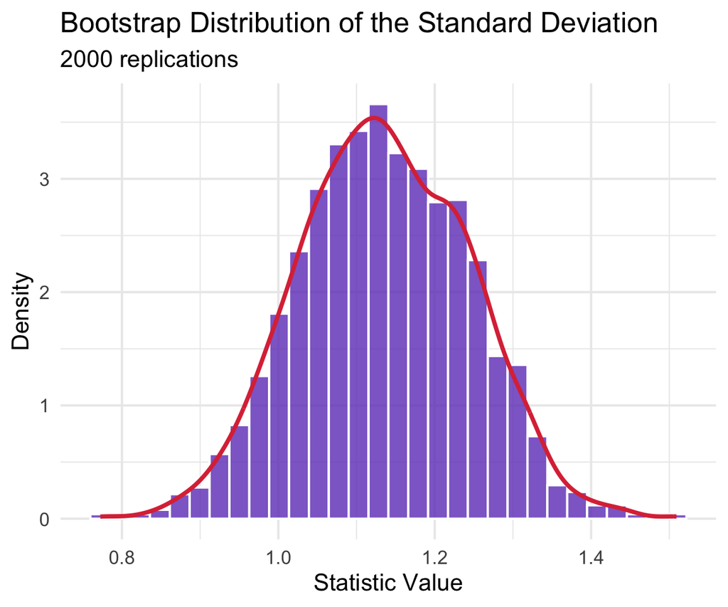

```r
boot_sd_stats <- replicate(B, {
  boot_sample <- sample(original_sample, size = n_sample, replace = TRUE)
  sd(boot_sample)
})

ggplot(data.frame(statistic = boot_sd_stats), aes(x = statistic)) +
  geom_histogram(aes(y = after_stat(density)), bins = 30, fill = "#6f42c1", color = "white", alpha = 0.8) +
  geom_density(color = "#dc3545", linewidth = 1.2) +
  labs(title = "Bootstrap Distribution of the Standard Deviation", subtitle = paste(B, "replications"),
       x = "Statistic Value", y = "Density") +
  theme_minimal(base_size = 14)
```